# RocketFuel

Manish Grewal

17/07/2020

## 1. Was the advertising campaign effective? Did additional consumers convert as a result of the ad campaign?

#### Number of users:

|  | control | test |
| --- | --- | --- |
| not-converted | 23104 | 550154 |
| converted | 420 | 14423 |

#### Proportion of users as percent:

|  | control | test |
| --- | --- | --- |
| not-converted | 98.214589 | 97.445344 |
| converted | 1.785411 | 2.554656 |

#### Mosaicplot

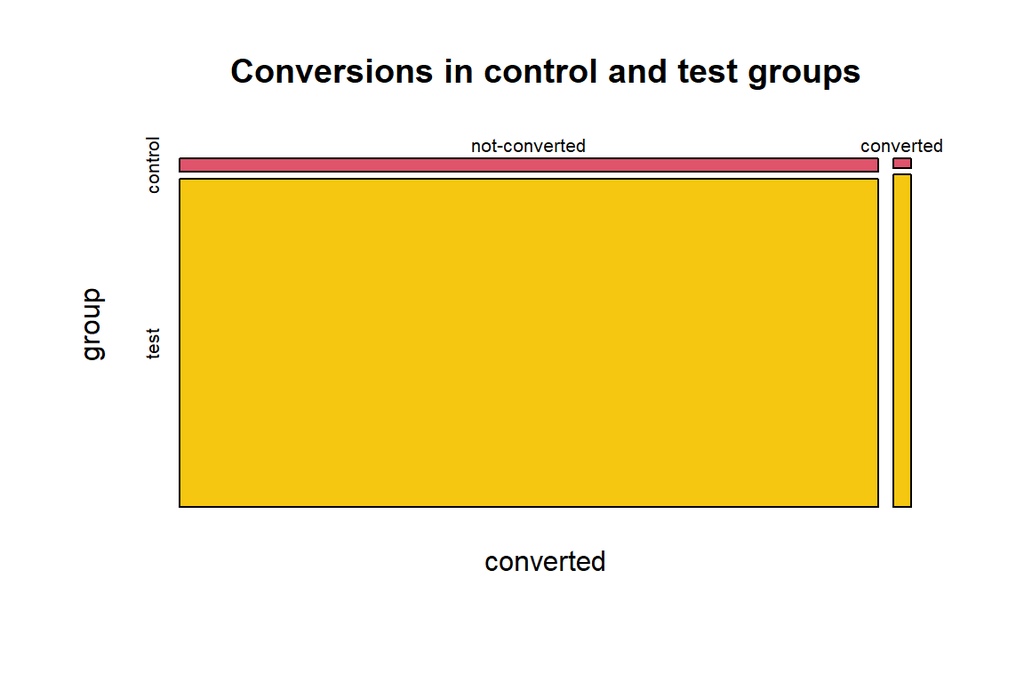

The conversion rate of exposed group 2.555% is greater than the conversion rate for control group 1.785%.

1.785% of users in the test group would have converted even without the ad impressions.

2.555% - 1.785% = 0.769% additional users in the test group have converted.

### t-test to check bias:

```r
t.test(dat$tot_impr ~dat$ftest)
```

```
##
##  Welch Two Sample t-test
##
## data:  dat$tot_impr by dat$ftest
## t = -0.218, df = 25608, p-value = 0.8274
## alternative hypothesis: true difference in means is not equal to 0
## 95 percent confidence interval:
##  -0.6217286  0.4972735
## sample estimates:
## mean in group control    mean in group test
##              24.76114              24.82337
```

As the mean of total impressions for the control and test groups are almost the same, and the t-value is reported as insignificant, we do not detect a bias in the total impressions for the control group and test group.

## 2. Was the campaign profitable?

### a. How much more money did TaskaBella make by running the campaign (excluding advertising costs)?

Number of users in exposed group = 564577  
Profit per conversion = $40

**Additional profit**  
= lift * (Number of users in exposed group) * (Profit per conversion) / 100  
= lift * num_exposed * 40 / 100  
= 0.7692453 * 564577 * 40 / 100  
= 173719.2858357

**Additional profit** = $173719.29

## b. What was the cost of the campaign?

Cost per 1000 (CPM) = 9

**Cost of campaign**  
= tot_impr * CPM / 1000  
= 14597182 * 9 / 1000  
= 131374.638

**Cost of campaign** = $131374.64

## c. Calculate the ROI of the campaign. Was the campaign profitable?

**ROI**  
= (addl_profit - cost_campaign) / cost_campaign * 100  
= 173719.2858357 - 131374.638 / 131374.638 * 100  
= 32.2319806

**ROI** = 32.23%

Yes, The campaign was profitable as ROI was good.

## d. What was the opportunity cost of including a control group; how much more could have TaskaBella made with a smaller control group or not having a control group at all?

**Opportunity Cost**  
= lift * (number of users in control group) * (Profit per conversion) / 100  
= lift * num_control * 40 / 100  
= 0.7692453 * 23524 * 40 / 100  
= $7238.2907557

**Opportunity Cost** = $7238.29

If the control group had been shown ads for the product instead of PSA, an additional profit of $7238.2907557 could have been obtained.

## 3. How did the number of impressions seen by each user influence the effectiveness of advertising?

### a.1 Create a chart of conversion rates as a function of the number of ads displayed to users.

#### Conversion rates by total_impr - Overall

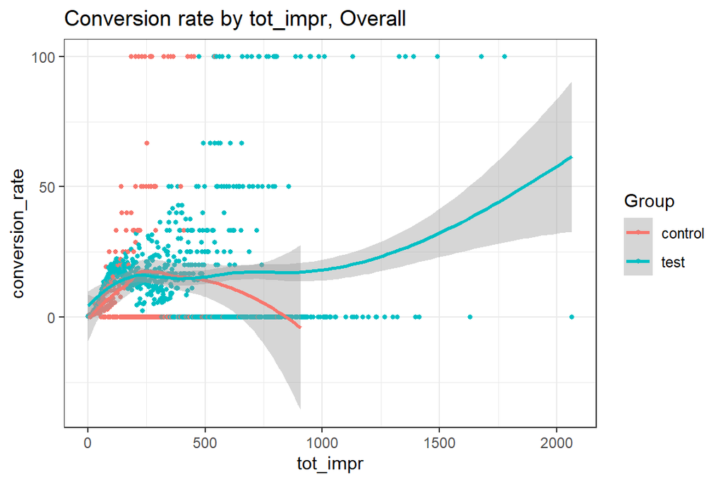

The scatter plot does not show a clear pattern. The number of points decrease as the total impressions increase, suggesting a presence of outliers. We bin the data using equal width and equal frequency binning to see if a patter emerges.

#### Conversion rates by total_impr - Overall - Equal width binning

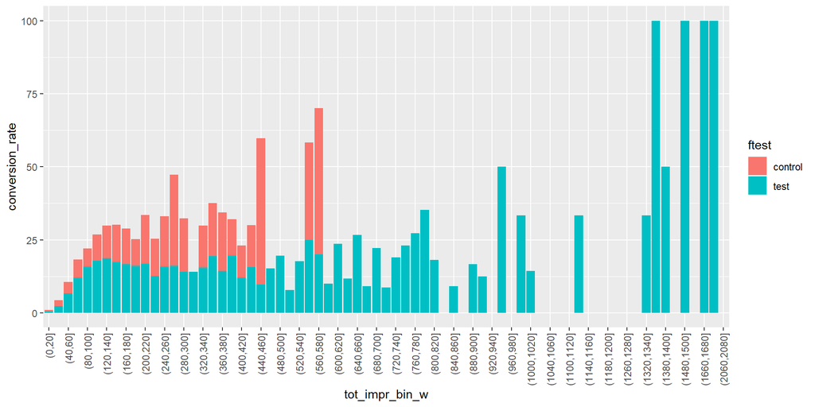

[figure not shown]

We observe a steady increase in conversion rate till around (120, 140] total impressions. Further increase in total impressions slightly reduces the conversion rate till (320,340] total impressions. Further increase in total impressions leads to an erratic conversion rate which sometimes falls to 0 for certain values of total impressions or increases dramatically. We need to keep in mind the number of users under each bin is steadily decreasing with increasing total impressions.

#### Conversion rates by total_impr - Overall - Equal frequency binning

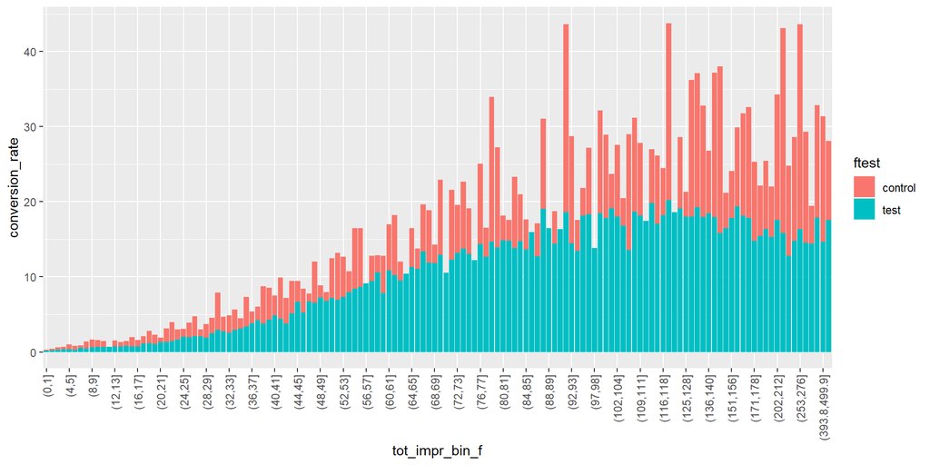

### 3.a.2 Plot conversion rates for those who were in the control group and for those who were exposed to the ad.

#### conversion rates by total_impr - Control Group

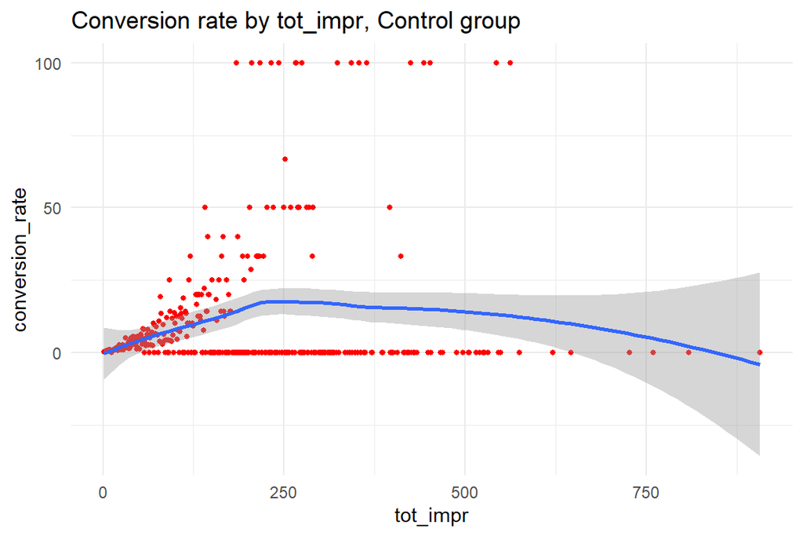

#### conversion rates vs. total_impr - Exposed Group

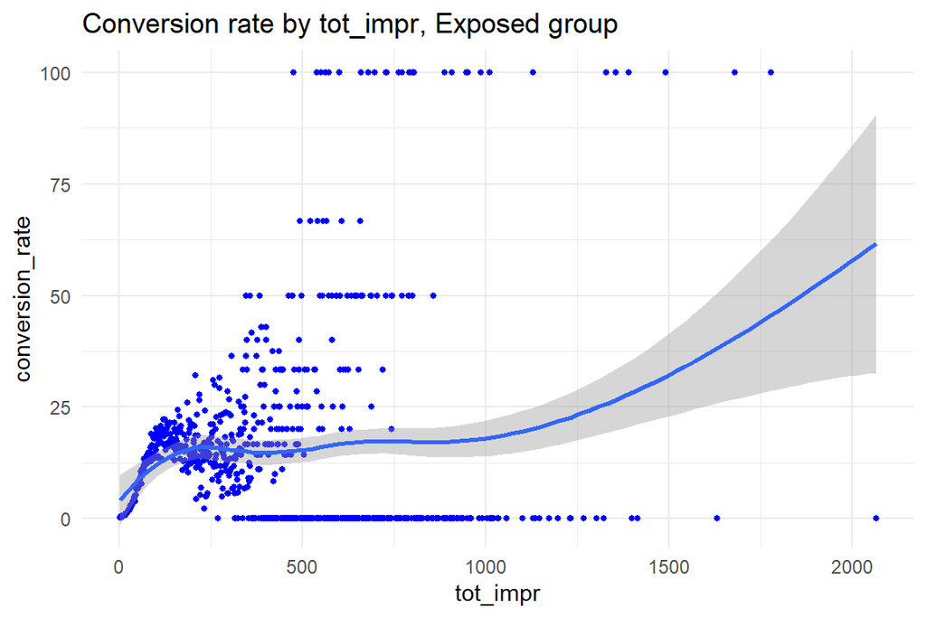

### 3.a.3 Group together number of impressions as necessary to obtain a meaningful plot.

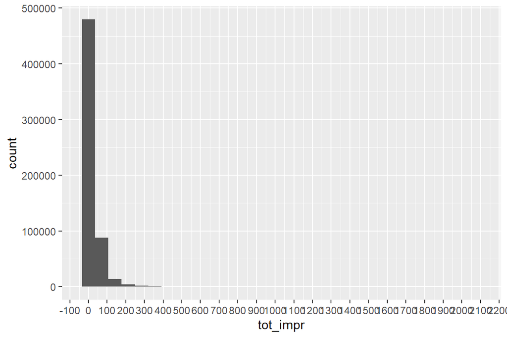

```
##   5%  10%  15%  20%  25%  30%  35%  40%  45%  50%  55%  60%  65%  70%  75%  80%
##    1    1    2    3    4    5    6    8   10   12   15   16   18   21   25   29
##  85%  90%  95% 100%
##   36   46   62  100
```

```
##    (1,2]    (2,3]    (3,4]    (4,5]    (5,6]    (6,8]   (8,10]  (10,12]
##    39827    28661    23426    29303    23409    35132    24411    26477
##  (12,15]  (15,16]  (16,18]  (18,21]  (21,25]  (25,29]  (29,36]  (36,46]
##    42250    13467    26360    27313    33380    22350    30833    27341
##  (46,62] (62,100]     NA's
##    26704    27787    56606
```

```
##    Min. 1st Qu.  Median    Mean 3rd Qu.    Max.
##    1.00    4.00   12.00   18.33   25.00  100.00
```

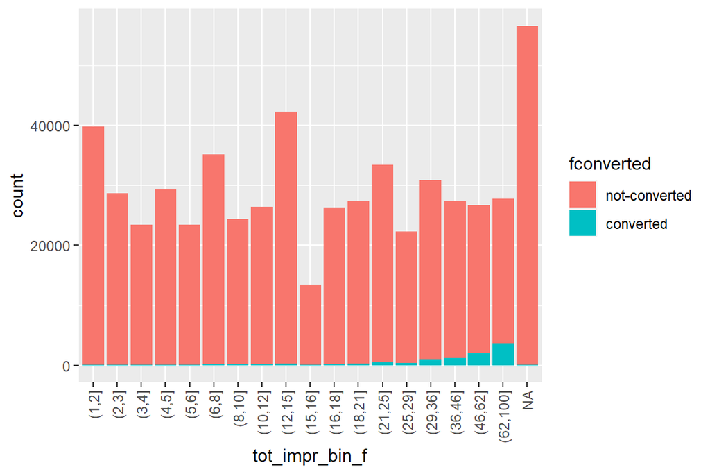

[figure not shown]

#### Equal width binning

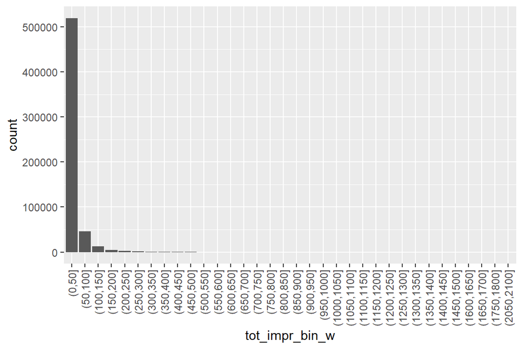

#### Equal frequency binning

```
##   0%  20%  40%  60%  80% 100%
##    1    3    8   17   33 2065
```

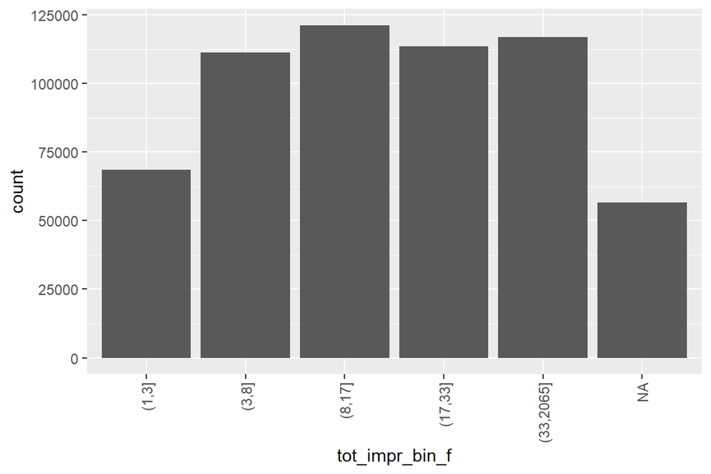

## b. What can you infer from the charts? In what region is advertising most effective?

The conversion rate increases as the number of impressions is increased. However, as the number of impressions is increased beyond a limit (appears to be 250), we see a flattening of the smoothing curve and also a concentration of non conversions. Need to zoom in to the chart to get a better picture.

## c. What do the above figures imply for the design of the next campaign assuming that consumer response would be similar?

Total impressions can be limited to up to 500 to ensure cost savings. At higher number of impression, conversion rate can dip unexpectedly.

# 4. How does consumer response to advertising vary on different days of the week and at different times of the day?

## a. Create a chart with the conversion rates for the control group and the exposed group as a function of the day of week when they were shown the most impressions.

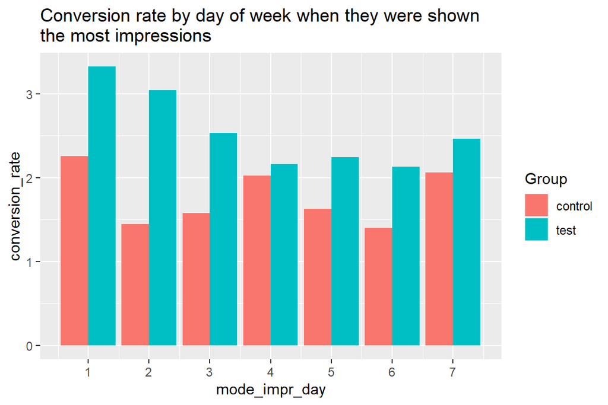

## b. Create the same chart for hours within a day (excluding the period between midnight and 8 a.m.).

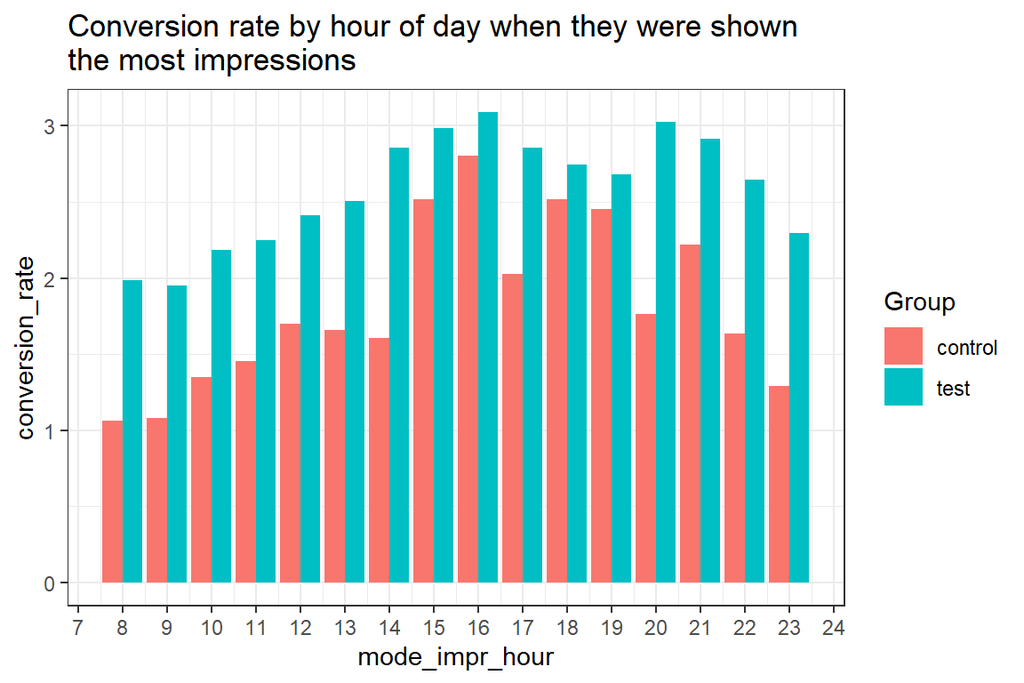

## c. What days/hours is advertising most/least effective?

#### From the graph, we can read the highest and lowest values for the exposed group. We can also cross check by arranging summ_day and summ_hour variables by conversion rate

### Most effective day

| mode_impr_day | ftest | conversion_rate |
| --- | --- | --- |
| 1 | test | 3.32412 |

#### => Most effective on Mondays.

### Least effective day

| mode_impr_day | ftest | conversion_rate |
| --- | --- | --- |
| 6 | test | 2.130657 |

#### => Least effective on Saturdays

### Most effective hour

| mode_impr_hour | ftest | conversion_rate |
| --- | --- | --- |
| 16 | test | 3.089286 |

#### => Most effective between 4 to 5 pm

### Least effective hour

[output not shown]